# Лабораторная работа № 6. Основы интерфейса взаимодействия пользователя с системой Unix на уровне командной строки

НПИбд-03-25

Author

Чжу Ино

Published

2026-10-14

# 1 Цель работы

Приобретение практических навыков взаимодействия пользователя с системой посредством командной строки.

# 2 Задачи

1. Определить полное имя домашнего каталога.
2. Выполнить операции с каталогами `/tmp`, `/var/spool`.
3. Создать и удалить каталоги `newdir`, `morefun`, `letters`, `memos`, `misk`.
4. С помощью `man` определить опции команд `ls`, `cd`, `pwd`, `mkdir`, `rmdir`, `rm`.
5. Использовать `history` для модификации и исполнения команд.

# 3 Теоретические сведения

## 3.1 Формат команды

```
<имя_команды> <разделитель> <аргументы>
```

## 3.2 Команда man

```bash
man <команда>
```

Управление: `Space` — страница вперёд, `Enter` — строка вперёд, `q` — выход.

## 3.3 Команда cd

```bash
cd [путь_к_каталогу]
```

## 3.4 Команда ls

```bash
ls [-опции] [путь]
```

- `-a` — показать скрытые файлы
- `-F` — показать тип файла
- `-l` — подробная информация
- `-R` — рекурсивно

## 3.5 Команда mkdir

```bash
mkdir имя_каталога1 [имя_каталога2...]
```

- `-m` — атрибуты доступа
- `-p` — создать родительские каталоги

## 3.6 Команда rm

```bash
rm [-опции] [файл]
```

- `-i` — подтверждение
- `-r` — рекурсивно

## 3.7 Команда history

```bash
history
!<номер>
!<номер>:s/<что_меняем>/<на_что_меняем>
```

# 4 Выполнение лабораторной работы

## 4.1 Определение домашнего каталога

```bash
pwd
```

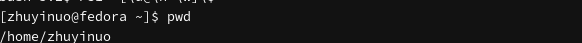

Figure 1: Домашний каталог

## 4.2 Работа с каталогом /tmp

```bash
cd /tmp
ls
```

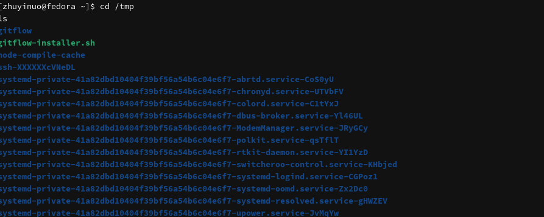

Figure 2: Содержимое /tmp

## 4.3 Опции команды ls

```bash
ls -a
ls -F
ls -l
ls -alF
```

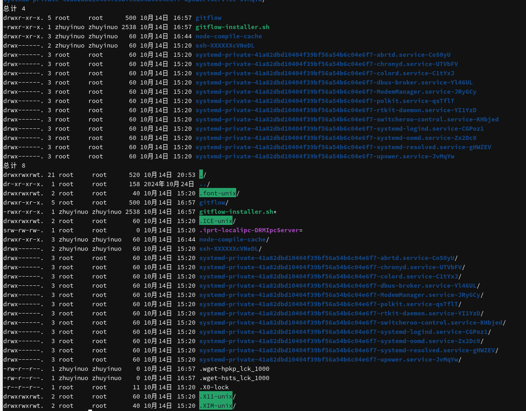

Figure 3: Опции ls

## 4.4 Проверка /var/spool

```bash
ls /var/spool/
ls /var/spool/cron
```

[figure not shown]

Figure 4: Проверка /var/spool

Подкаталог `cron` в `/var/spool` отсутствует.

## 4.5 Домашний каталог

```bash
cd ~
pwd
ls -la
```

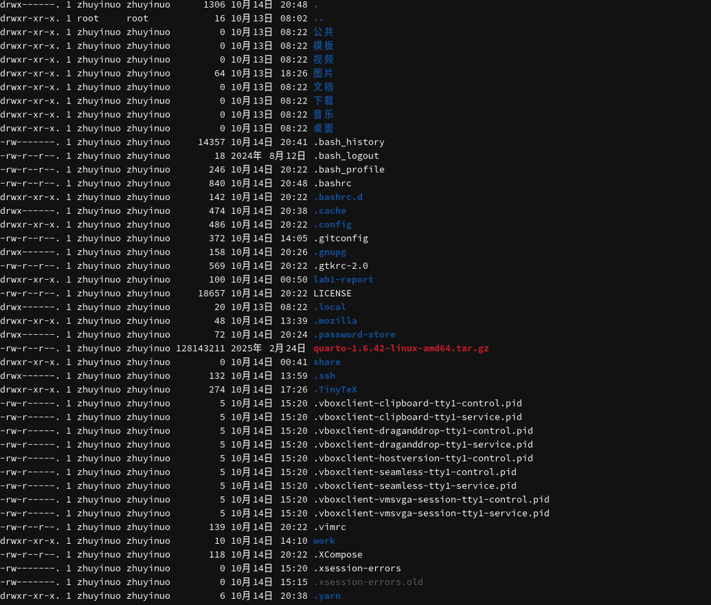

Figure 5: Домашний каталог

## 4.6 Создание каталогов newdir и morefun

```bash
mkdir ~/newdir
mkdir ~/newdir/morefun
ls -la ~/newdir
```

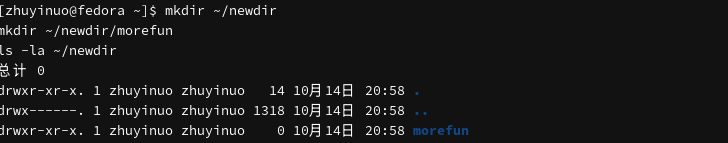

Figure 6: Создание newdir

## 4.7 Создание трёх каталогов

```bash
cd ~
mkdir letters memos misk
ls
```

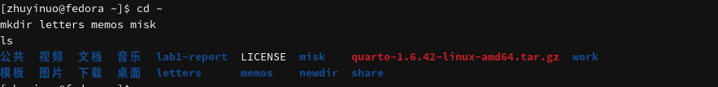

Figure 7: Создание трёх каталогов

## 4.8 Удаление трёх каталогов

```bash
rmdir letters memos misk
ls
```

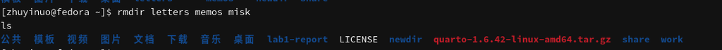

Figure 8: Удаление трёх каталогов

## 4.9 Попытка удалить newdir командой rm

```bash
rm ~/newdir
ls ~/
```

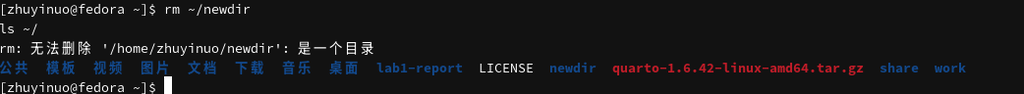

Figure 9: rm newdir

Каталог не был удалён, так как `rm` без опции `-r` не удаляет каталоги.

## 4.10 Удаление morefun

```bash
rmdir ~/newdir/morefun
ls ~/newdir
```

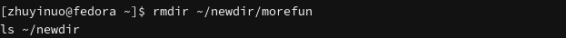

Figure 10: Удаление morefun

## 4.11 Опция ls -R

```bash
man ls
```

Опция `-R` позволяет просмотреть содержимое указанного каталога и всех подкаталогов.

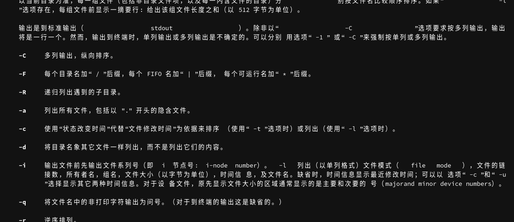

Figure 11: man ls -R

## 4.12 Опции ls -lt

```bash
man ls
```

Опции `-l` и `-t` позволяют вывести подробную информацию с сортировкой по времени последнего изменения.

[figure not shown]

Figure 12: man ls -lt

## 4.13 man cd и pwd

```bash
man cd
man pwd
```

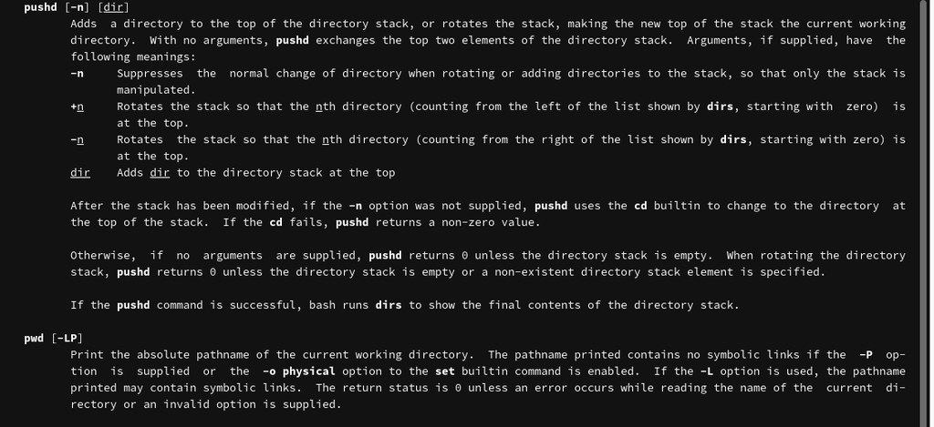

Figure 13: man cd pwd

## 4.14 man mkdir, rmdir, rm

```bash
man mkdir
man rmdir
man rm
```

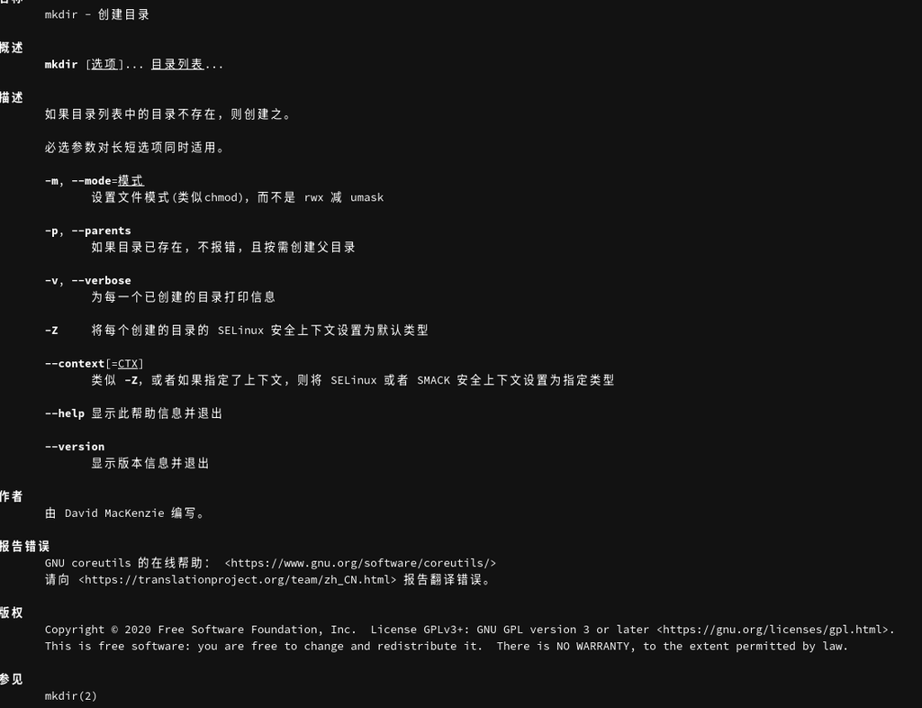

Figure 14: man mkdir rm

## 4.15 history

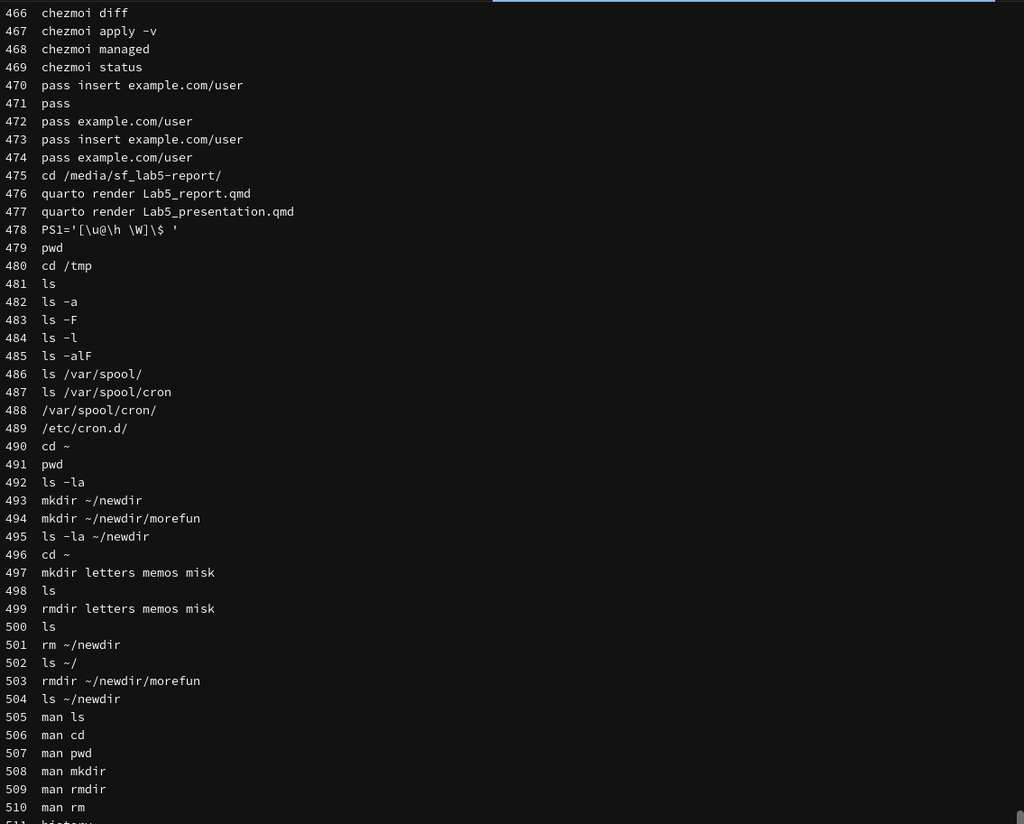

Figure 15: history

```bash
history
```

## 4.16 Повтор команды

```bash
!5
```

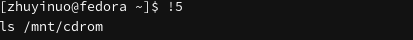

Figure 16: Повтор команды

## 4.17 Модификация команды

```bash
!3:s/a/F
```

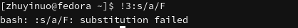

Figure 17: Модификация команды

# 5 Выводы

В ходе работы приобретены практические навыки взаимодействия с системой Unix посредством командной строки: изучены команды `man`, `cd`, `ls`, `mkdir`, `rm`, `rmdir`, `history`, освоены их основные опции.

# 6 Контрольные вопросы

**1. Что такое командная строка?**

Интерфейс взаимодействия пользователя с системой посредством ввода команд.

**2. Как определить абсолютный путь текущего каталога?**

```bash
pwd
```

**3. Как определить тип файлов и их имена?**

```bash
ls -F
```

**4. Как отобразить скрытые файлы?**

```bash
ls -a
```

**5. Как удалить файл и каталог?**

- Файл: `rm file`
- Пустой каталог: `rmdir dir`
- Каталог с файлами: `rm -r dir`

Одной командой — `rm -r`.

**6. Как вывести последние выполненные команды?**

```bash
history
```

**7. Как модифицированно выполнить команду из истории?**

```bash
!<номер>:s/<что_меняем>/<на_что_меняем>
```

**8. Примеры запуска нескольких команд в одной строке.**

```bash
cd ~ && ls -la
mkdir dir1; mkdir dir2
```

**9. Символы экранирования.**

`\`, `'`, `"`, `$`, `` ` ``.

**10. Вывод команды ls -l.**

Тип файла, права доступа, число ссылок, владелец, размер, дата, имя.

**11. Относительный путь.**

Путь относительно текущего каталога: `../dir1`, `./file`.

**12. Как получить информацию о команде?**

```bash
man <команда>
```

**13. Клавиша автодополнения.**

`Tab`.

# 7 Список литературы

1. Робачевский А., Немнюгин С., Стесик О. Операционная система UNIX. — БХВ-Петербург, 2010.
2. Колисниченко Д. Н. Самоучитель системного администратора Linux. — БХВ-Петербург, 2011.
3. Таненбаум Э., Бос Х. Современные операционные системы. — Питер, 2015.